# Linear Regression Analysis

MPA 6020 (Spring 2016)

2016-03-14

# Simple Linear Regression

Recall the fundamentals of a linear regression model. In brief, you have

- $y =$ a continuous dependent variable
- $x_{i} =$ one or more independent variables that might be qualitative (categorical, nominal or ordinal) and/or quantitative (continuous/discrete, ratio or interval)
- the existence of a linear relationship between the dependent and the independent variables
- Some assumptions that, if met, ensure that our slope coefficients $(\hat{beta}_i)$ are the best linear unbiased estimates (BLUE)

Let us fit a simple linear regression model to the `sowc` data, with U5MR as the dependent variable.

```r
load("~/Downloads/sowc.RData")
lm.1 = lm(U5MR ~ Income, data = sowc)
summary(lm.1)
```

```
##
## Call:
## lm(formula = U5MR ~ Income, data = sowc)
##
## Residuals:
##    Min     1Q Median     3Q    Max
## -38.65 -26.53 -12.68  18.29 129.71
##
## Coefficients:
##               Estimate Std. Error t value Pr(>|t|)
## (Intercept) 53.2358231  3.7144805  14.332  < 2e-16 ***
## Income      -0.0016308  0.0002899  -5.625 1.07e-07 ***
## ---
## Signif. codes:  0 '***' 0.001 '**' 0.01 '*' 0.05 '.' 0.1 ' ' 1
##
## Residual standard error: 35.09 on 131 degrees of freedom
## Multiple R-squared:  0.1946, Adjusted R-squared:  0.1884
## F-statistic: 31.65 on 1 and 131 DF,  p-value: 1.072e-07
```

Note the structure of the command …

- `lm()` stands for a linear model. I have chosen an arbitray name for this regression, calling it `lm.1`
- We specify the regression equation as `lm(dependent ~ independent, data = dataset)`
- We then check the resulting estimates via `summary(lm.1)`

## Interpreting the Estimates

How might we interpret our results? Just as we did before. That is:

- When Income is 0, U5MR is predicted to be 53.23 (i.e., 53 infant mortalities per 1000 live births)
- For every $1 increase in Income, U5MR is predicted to decrease by 0.0016 infant mortalities per 1000 live births
- The adjusted $R^2$ is 0.1884; so this model explains about 18.84% of the variation in U5MR
- The Residual standard error (the RMSE) is 35.09, indicating that on average our prediction error, based on this model, will be $\pm 35.09$ infant mortalities

## Generating Predicted Values

We can generate predicted values with relative ease, and then plot these as well.

```r
new.data = data.frame(Income = seq(0, 80000, by = 1000))

predicted1 = predict(lm.1, interval = "confidence", conf.level = 0.95,
    data = new.data)
head(predicted1)
```

| fit | lwr | upr |
| --- | --- | --- |
| 46.56587 | 40.26342 | 52.86831 |
| 46.53325 | 40.23420 | 52.83230 |
| 45.76678 | 39.54192 | 51.99163 |
| 47.16926 | 40.80063 | 53.53789 |
| 43.36950 | 37.30482 | 49.43418 |
| 27.06154 | 19.24410 | 34.87898 |

```r
colnames(predicted1) = c("predicted.U5MR1", "lwr1", "upr1")
head(predicted1)
```

| predicted.U5MR1 | lwr1 | upr1 |
| --- | --- | --- |
| 46.56587 | 40.26342 | 52.86831 |
| 46.53325 | 40.23420 | 52.83230 |
| 45.76678 | 39.54192 | 51.99163 |
| 47.16926 | 40.80063 | 53.53789 |
| 43.36950 | 37.30482 | 49.43418 |
| 27.06154 | 19.24410 | 34.87898 |

```r
predicted2 = predict(lm.1, interval = "prediction", conf.level = 0.95,
    data = new.data)
head(predicted2)
```

| fit | lwr | upr |
| --- | --- | --- |
| 46.56587 | -23.12982 | 116.26156 |
| 46.53325 | -23.16213 | 116.22863 |
| 45.76678 | -23.92194 | 115.45549 |
| 47.16926 | -22.53245 | 116.87097 |
| 43.36950 | -26.30509 | 113.04410 |
| 27.06154 | -42.78745 | 96.91053 |

```r
colnames(predicted2) = c("predicted.U5MR2", "lwr2", "upr2")
head(predicted2)
```

| predicted.U5MR2 | lwr2 | upr2 |
| --- | --- | --- |
| 46.56587 | -23.12982 | 116.26156 |
| 46.53325 | -23.16213 | 116.22863 |
| 45.76678 | -23.92194 | 115.45549 |
| 47.16926 | -22.53245 | 116.87097 |
| 43.36950 | -26.30509 | 113.04410 |
| 27.06154 | -42.78745 | 96.91053 |

```r
df = cbind.data.frame(sowc, predicted1, predicted2)
```

## Plots

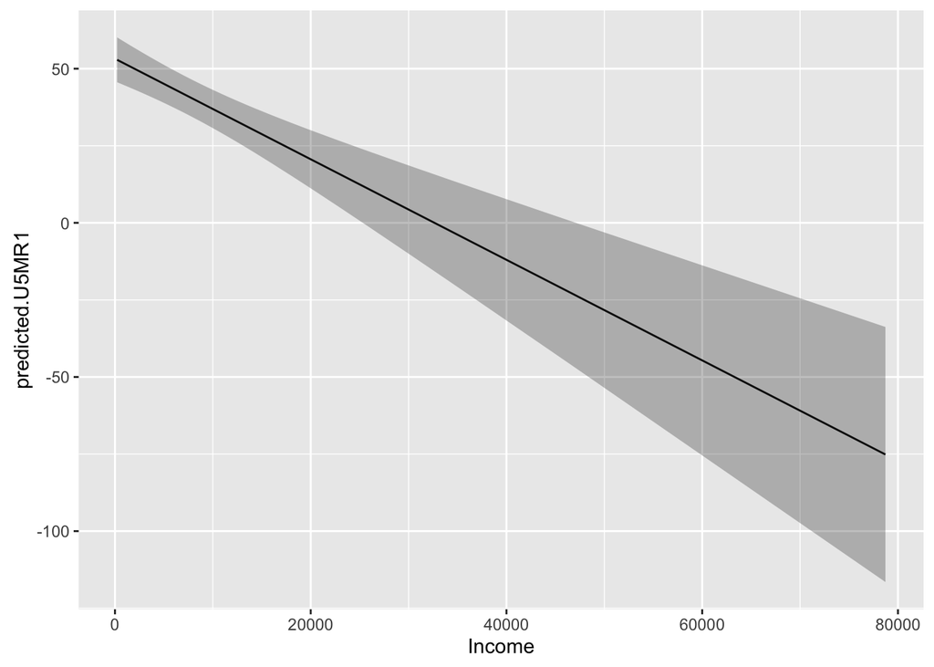

```r
library(ggplot2)

p1 = ggplot(data = df, aes(x = Income, y = predicted.U5MR1)) +
    geom_line() + geom_ribbon(data = df, aes(ymin = lwr1, ymax = upr1),
    alpha = 0.3)
p1
```

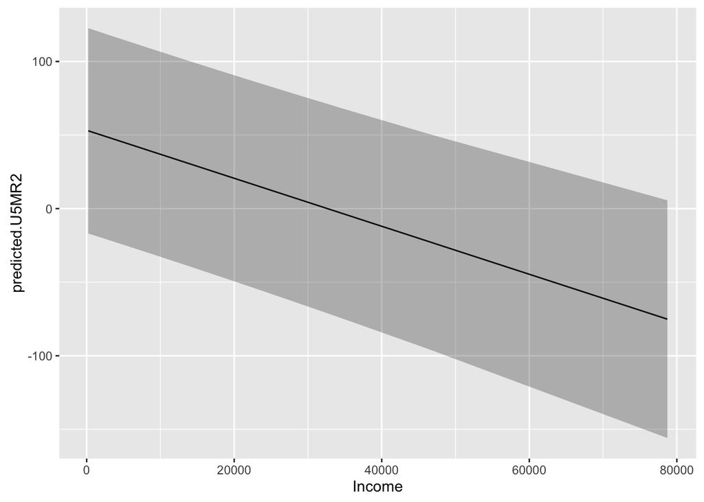

```r
p2 = ggplot(data = df, aes(x = Income, y = predicted.U5MR2)) +
    geom_line() + geom_ribbon(data = df, aes(ymin = lwr2, ymax = upr2),
    alpha = 0.3)
p2
```

### Dummy Independent variables

Assume that we are also interested in seeing if U5MR also differs according to whether a country is flagged as **Urban** or as **Rural**. So we include this independent variable in our model.

```r
sowc$Urban_Rural[sowc$Urban > 50] = "Urban"
sowc$Urban_Rural[sowc$Urban <= 50] = "Rural"

lm.2 = lm(U5MR ~ Income + Urban_Rural, data = sowc)
summary(lm.2)
```

```
##
## Call:
## lm(formula = U5MR ~ Income + Urban_Rural, data = sowc)
##
## Residuals:
##     Min      1Q  Median      3Q     Max
## -54.188 -16.837  -8.108  10.429 132.540
##
## Coefficients:
##                    Estimate Std. Error t value Pr(>|t|)
## (Intercept)       6.620e+01  4.362e+00  15.175  < 2e-16 ***
## Income           -1.077e-03  2.916e-04  -3.694 0.000324 ***
## Urban_RuralUrban -2.980e+01  6.185e+00  -4.819 3.96e-06 ***
## ---
## Signif. codes:  0 '***' 0.001 '**' 0.01 '*' 0.05 '.' 0.1 ' ' 1
##
## Residual standard error: 32.44 on 130 degrees of freedom
## Multiple R-squared:  0.3166, Adjusted R-squared:  0.3061
## F-statistic: 30.12 on 2 and 130 DF,  p-value: 1.787e-11
```

Watch the coefficient on Urban_Rural. First, you see the coefficient estimated for `Urban` and the value is -29.80, indicating that holding all else constant there are almost 30 fewer infant mortalities per 1000 live briths in an Urban country as compared to in a Rural country.

### Interaction Effects

Recall the discussion about a model with interactions. Briefly, this might be:

$$U5MR = \beta_0 + \beta_1(Income) + \beta_2(Urban\_Rural) + \beta_4(Income \times Urban\_Rural)$$

If it is an Urban country, then the equation becomes:

$$U5MR = \beta_0 + \beta_1(Income) + \beta_2(Urban) + \beta_4(Income \times Urban)$$

If it is a Rural country, then the equation becomes:

$$U5MR = \beta_0 + \beta_1(Income)$$

```r
lm.3 = lm(U5MR ~ Income + Urban_Rural + Income:Urban_Rural, data = sowc)
summary(lm.3)
```

```
##
## Call:
## lm(formula = U5MR ~ Income + Urban_Rural + Income:Urban_Rural,
##     data = sowc)
##
## Residuals:
##     Min      1Q  Median      3Q     Max
## -52.025 -16.480  -9.149   8.979 133.984
##
## Coefficients:
##                           Estimate Std. Error t value Pr(>|t|)
## (Intercept)              73.926165   5.004014  14.773  < 2e-16 ***
## Income                   -0.004076   0.001068  -3.816  0.00021 ***
## Urban_RuralUrban        -40.018345   6.962291  -5.748 6.19e-08 ***
## Income:Urban_RuralUrban   0.003226   0.001108   2.912  0.00424 **
## ---
## Signif. codes:  0 '***' 0.001 '**' 0.01 '*' 0.05 '.' 0.1 ' ' 1
##
## Residual standard error: 31.55 on 129 degrees of freedom
## Multiple R-squared:  0.3588, Adjusted R-squared:  0.3439
## F-statistic: 24.06 on 3 and 129 DF,  p-value: 1.97e-12
```

Note: R is using Urban as the group to be modeled, which means if we are interested in the Rural group we’ll have to cancel any term with `Urban_RuralUrban` in it.